# HR Data Analysis Report

## Introduction

This report analyzes the HR dataset to gain insights into employee demographics, performance, and other key factors.

#### Import necessary libraries

```python
import pandas as pd
import numpy as np
import matplotlib.pyplot as plt
%matplotlib inline
import seaborn as sns
```

#### Load HR dataset

```python
hr=pd.read_csv("HRDataset_v14.csv")
hr.head()
```

|  | Employee_Name | EmpID | MarriedID | PerfScoreID | Salary | Termd | Position | DOB | Sex | CitizenDesc | RaceDesc | EmploymentStatus | Department | ManagerName | RecruitmentSource | PerformanceScore | SpecialProjectsCount | Absences |
| --- | --- | --- | --- | --- | --- | --- | --- | --- | --- | --- | --- | --- | --- | --- | --- | --- | --- | --- |
| 0 | Adinolfi, Wilson K | 10026 | 0 | 4 | 62506 | 0 | Production Technician I | 07/10/1983 | M | US Citizen | White | Active | Production | Michael Albert | LinkedIn | Exceeds | 0 | 1 |
| 1 | Ait Sidi, Karthikeyan | 10084 | 1 | 3 | 104437 | 1 | Sr. DBA | 05/05/1975 | M | US Citizen | White | Voluntarily Terminated | IT/IS | Simon Roup | Indeed | Fully Meets | 6 | 17 |
| 2 | Akinkuolie, Sarah | 10196 | 1 | 3 | 64955 | 1 | Production Technician II | 09/19/88 | F | US Citizen | White | Voluntarily Terminated | Production | Kissy Sullivan | LinkedIn | Fully Meets | 0 | 3 |
| 3 | Alagbe,Trina | 10088 | 1 | 3 | 64991 | 0 | Production Technician I | 09/27/88 | F | US Citizen | White | Active | Production | Elijiah Gray | Indeed | Fully Meets | 0 | 15 |
| 4 | Anderson, Carol | 10069 | 0 | 3 | 50825 | 1 | Production Technician I | 09/08/1989 | F | US Citizen | White | Voluntarily Terminated | Production | Webster Butler | Google Search | Fully Meets | 0 | 2 |

#### Display basic statistics

```python
hr.describe()
```

|  | EmpID | MarriedID | PerfScoreID | Salary | Termd | SpecialProjectsCount | Absences |
| --- | --- | --- | --- | --- | --- | --- | --- |
| count | 311.000000 | 311.000000 | 311.000000 | 311.000000 | 311.000000 | 311.000000 | 311.000000 |
| mean | 10156.000000 | 0.398714 | 2.977492 | 69020.684887 | 0.334405 | 1.218650 | 10.237942 |
| std | 89.922189 | 0.490423 | 0.587072 | 25156.636930 | 0.472542 | 2.349421 | 5.852596 |
| min | 10001.000000 | 0.000000 | 1.000000 | 45046.000000 | 0.000000 | 0.000000 | 1.000000 |
| 25% | 10078.500000 | 0.000000 | 3.000000 | 55501.500000 | 0.000000 | 0.000000 | 5.000000 |
| 50% | 10156.000000 | 0.000000 | 3.000000 | 62810.000000 | 0.000000 | 0.000000 | 10.000000 |
| 75% | 10233.500000 | 1.000000 | 3.000000 | 72036.000000 | 1.000000 | 0.000000 | 15.000000 |
| max | 10311.000000 | 1.000000 | 4.000000 | 250000.000000 | 1.000000 | 8.000000 | 20.000000 |

#### Display dataset information

```python
hr.info()
```

```
<class 'pandas.core.frame.DataFrame'>
RangeIndex: 311 entries, 0 to 310
Data columns (total 18 columns):
 #   Column                Non-Null Count  Dtype
---  ------                --------------  -----
 0   Employee_Name         311 non-null    object
 1   EmpID                 311 non-null    int64
 2   MarriedID             311 non-null    int64
 3   PerfScoreID           311 non-null    int64
 4   Salary                311 non-null    int64
 5   Termd                 311 non-null    int64
 6   Position              311 non-null    object
 7   DOB                   311 non-null    object
 8   Sex                   311 non-null    object
 9   CitizenDesc           311 non-null    object
 10  RaceDesc              311 non-null    object
 11  EmploymentStatus      311 non-null    object
 12  Department            311 non-null    object
 13  ManagerName           311 non-null    object
 14  RecruitmentSource     311 non-null    object
 15  PerformanceScore      311 non-null    object
 16  SpecialProjectsCount  311 non-null    int64
 17  Absences              311 non-null    int64
dtypes: int64(7), object(11)
memory usage: 43.9+ KB
```

#### Drop rows with missing values

```python
df=hr.dropna()
```

#### 1 : Employee Demographics:

**Question 1.1:What is the distribution of employees based on gender (Sex)?**

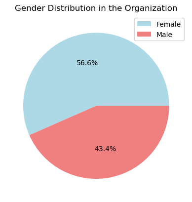

```python
#  Distribution based on gender (Sex)
plt.pie(df['Sex'].value_counts(), labels=['', ''], autopct='%1.1f%%', colors=['lightblue', 'lightcoral'])
# Customize the chart
plt.title('Gender Distribution in the Organization')
plt.legend(['Female','Male'])
# Show the chart
plt.show()
```

**Question 1.2:How is the workforce distributed across different races (RaceDesc)?**

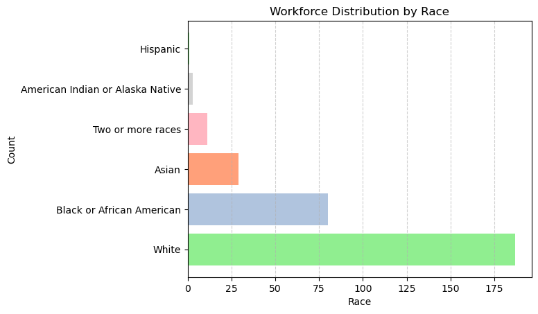

```python
colors = [  'lightgreen', 'lightsteelblue','lightsalmon', 'lightpink','lightgray' ]
plt.barh(df['RaceDesc'].value_counts().index, df['RaceDesc'].value_counts(),color=colors)
plt.title('Workforce Distribution by Race')
plt.xlabel('Race')
plt.ylabel('Count')
plt.grid(axis='x', linestyle='--', alpha=0.6)

plt.show()
```

#### 2 : Employment Status

**Question 2.1:What is the distribution of employees across different employment statuses (EmploymentStatus)?**

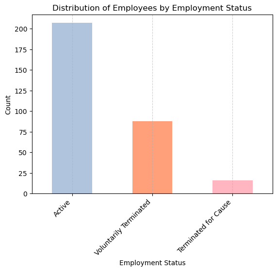

```python
colors = ['lightsteelblue','lightsalmon', 'lightpink','lightgray']
# Plot the distribution of employees by employment status
employment_status_distribution = df['EmploymentStatus'].value_counts()
employment_status_distribution.plot(kind='bar', color=colors)
plt.title('Distribution of Employees by Employment Status')
plt.xlabel('Employment Status')
plt.ylabel('Count')
# Tilt x-axis labels for better readability
plt.xticks(rotation=45, ha='right')
plt.grid(axis='x', linestyle='--', alpha=0.6)
plt.show()
```

#### 3 : Performance Analysis:

**Question 3.1:What is the distribution of employees based on performance scores (PerformanceScore)?**

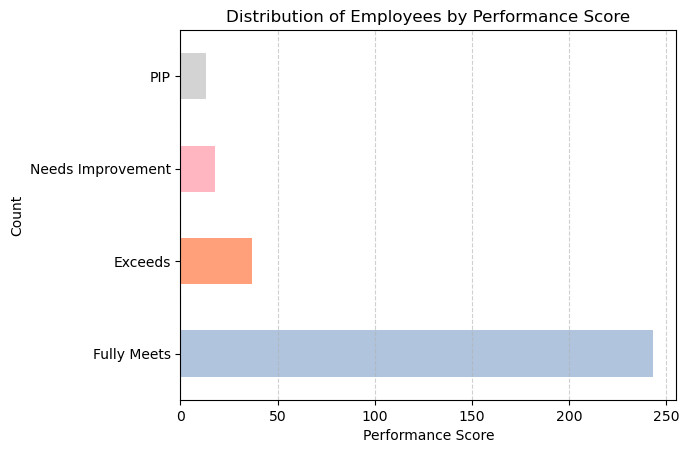

```python
# Question 3.1: Distribution of employees based on performance scores (PerformanceScore)
performance_distribution = df['PerformanceScore'].value_counts()
performance_distribution.plot(kind='barh', color=colors)
plt.title('Distribution of Employees by Performance Score')
plt.xlabel('Performance Score')
plt.ylabel('Count')
plt.grid(axis='x', linestyle='--', alpha=0.6)
plt.show()
```

#### 4 : Salary Insights:

**Question 4.1:"How does the distribution of salaries vary across different departments"**

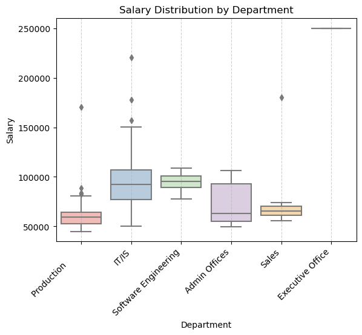

```python
sns.boxplot(x='Department', y='Salary', data=df, palette='Pastel1')
plt.title('Salary Distribution by Department')
plt.xticks(rotation=45, ha='right')
plt.grid(axis='x', linestyle='--', alpha=0.6)
plt.show()
```

#### 5 : Managerial Relationships

**Question 5.1: What is the distribution of performance scores for employees reporting to different managers?**

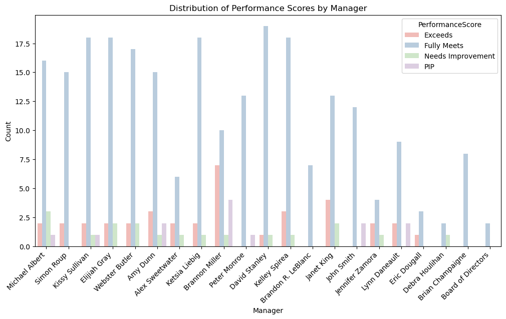

```python
# Question 5.2: Distribution of performance scores for employees reporting to different managers
plt.figure(figsize=(12, 6))
sns.countplot(x='ManagerName', hue='PerformanceScore', data=df, palette='Pastel1')
plt.title('Distribution of Performance Scores by Manager')
plt.xlabel('Manager')
plt.ylabel('Count')
plt.xticks(rotation=45, ha='right')
plt.show()
```

#### 6 : Recruitment Sources

**Question 6.1: Which recruitment sources (RecruitmentSource) are most commonly used to hire employees?**

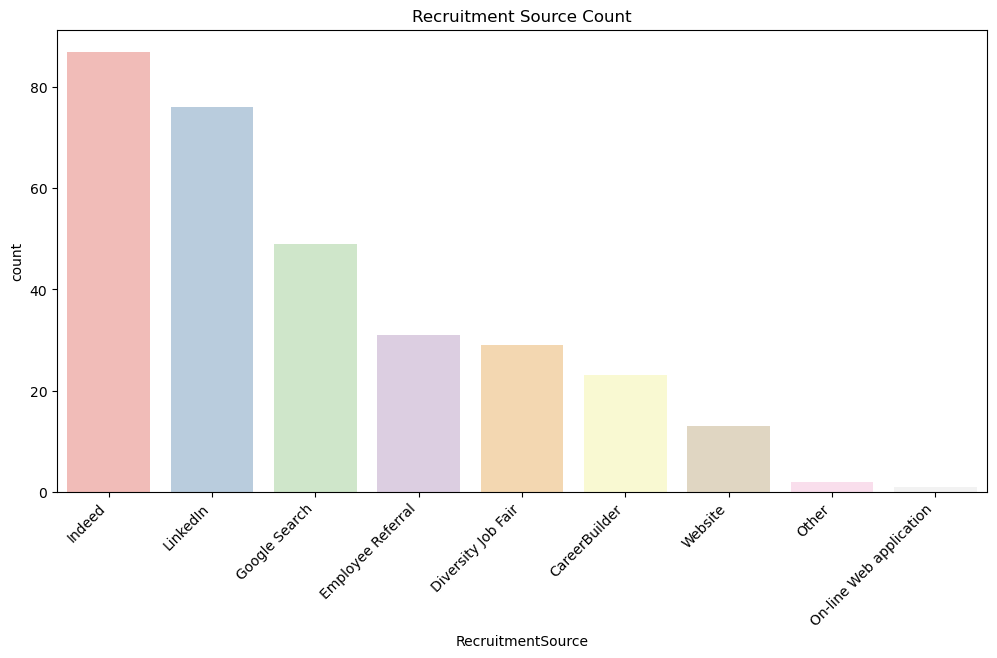

```python
# Question 6.1: Most commonly used recruitment sources
plt.figure(figsize=(12, 6))
sns.countplot(x='RecruitmentSource', data=df, palette='Pastel1', order=df['RecruitmentSource'].value_counts().index)
plt.title('Recruitment Source Count')
plt.xticks(rotation=45, ha='right')
plt.show()
```

#### 7: Marital Status

**Question 7.1: What is the distribution of employees based on marital status (MarriedID)?**

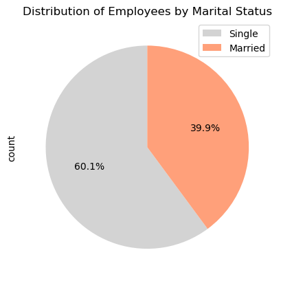

```python
# Question 7.1: Distribution of employees based on marital status
marital_status_distribution = df['MarriedID'].value_counts()
marital_status_distribution.plot(kind='pie', autopct='%1.1f%%', startangle=90, labels=(["",""]),colors=['lightgray','lightsalmon'])
plt.title('Distribution of Employees by Marital Status')
plt.legend(["Single","Married"])
plt.show()
```

## Conclusion

In conclusion, the analysis of the HR dataset has provided valuable insights into various aspects of the workforce. Key findings include:

- Gender distribution in the organization shows a higher representation of females compared to males.
- Workforce distribution by race indicates that the majority of employees are of White ethnicity.
- The top recruitment sources for the organization are Indeed and LinkedIn, highlighting their significance in talent acquisition.
- A significant portion of the workforce, comprising 60%, is unmarried according to the distribution by marital status.